# Gas Flux Data Analysis: Trends So Far

### Including the Dark Measurements

When I first tried extrapolating the photosynthesis models across time at collar TEH3 (see below), I received a bit of a shock: the model was predicting photosynthesis to occur at night! The model “knew” that photosynthesis decreases substantially at night, of course, but I hadn’t fed it the boundary condition of zero light so it didn’t know that zero light = zero photosynthesis. For the model below, I include all of the dark measurements. I’m not convinced that this is the best solution to the issue: including the dark measurements adds another layer of data replication, and I had to manually set all the photosynthetic fluxes to 0, which is a little different from our empirical flux measurements of light minus dark with associated measurement error (though I guess you could frame this as subtracting dark from dark…). That being said, I didn’t want to include only some dark measurements and mess with the sampling design, or swap out some dark measurements for light measurements and lose information. Here’s how the new model looks:

```r
# Create pared down table for respiration, shorten variable names (used in next section)
resp.sub = dark %>% select(CollarID, log.resp, CO2_flux_umol_m.2_sec.1, Water_Level_cm, Days_Since_Thaw, log.Biomass, Site, Mean_Temp_C_true_estimate, Soil_Temp_C, dec.hrs, bare) %>%
  rename(CO2_flux = CO2_flux_umol_m.2_sec.1,
         WL = Water_Level_cm,
         Day = Days_Since_Thaw,
         BM = log.Biomass,
         AirTemp = Mean_Temp_C_true_estimate,
         SoilTemp = Soil_Temp_C,
         Hr.of.Day = dec.hrs,
         Bare = bare)

# Make dark measurement table that conforms to existing photosynthesis table
dark.sub = resp.sub %>%
  select(-c(CO2_flux, Bare, SoilTemp, log.resp)) %>%
  mutate(Lux = rep(0, nrow(resp.sub)),
         raw.photo = rep(0, nrow(resp.sub)),
         log.photo = rep(0, nrow(resp.sub)), # ln(0 + 1) = 0 (using established offset)
# Combine light and dark measurements
         neg.photo = rep(0, nrow(resp.sub)))
ld.sub = rbind(photo.sub, dark.sub)

gam_phot3 = gam(log.photo ~ s(Lux, k=4) + s(WL, k=4) + s(Day, k=4) + s(BM, k=4) + Site, data = ld.sub, method = "REML")
summary(gam_phot3)
```

```
##
## Family: gaussian
## Link function: identity
##
## Formula:
## log.photo ~ s(Lux, k = 4) + s(WL, k = 4) + s(Day, k = 4) + s(BM,
##     k = 4) + Site
##
## Parametric coefficients:
##             Estimate Std. Error t value Pr(>|t|)
## (Intercept)  0.99043    0.06116  16.194   <2e-16 ***
## SiteMid     -0.23971    0.09724  -2.465   0.0142 *
## SiteWest    -0.07027    0.08304  -0.846   0.3981
## ---
## Signif. codes:  0 '***' 0.001 '**' 0.01 '*' 0.05 '.' 0.1 ' ' 1
##
## Approximate significance of smooth terms:
##          edf Ref.df       F  p-value
## s(Lux) 2.983  3.000 322.522  < 2e-16 ***
## s(WL)  2.658  2.912  11.382 2.31e-06 ***
## s(Day) 2.755  2.951   9.612 4.97e-05 ***
## s(BM)  1.882  2.253  17.056  < 2e-16 ***
## ---
## Signif. codes:  0 '***' 0.001 '**' 0.01 '*' 0.05 '.' 0.1 ' ' 1
##
## R-sq.(adj) =  0.784   Deviance explained = 79.3%
## -REML = 274.88  Scale est. = 0.2764    n = 324
```

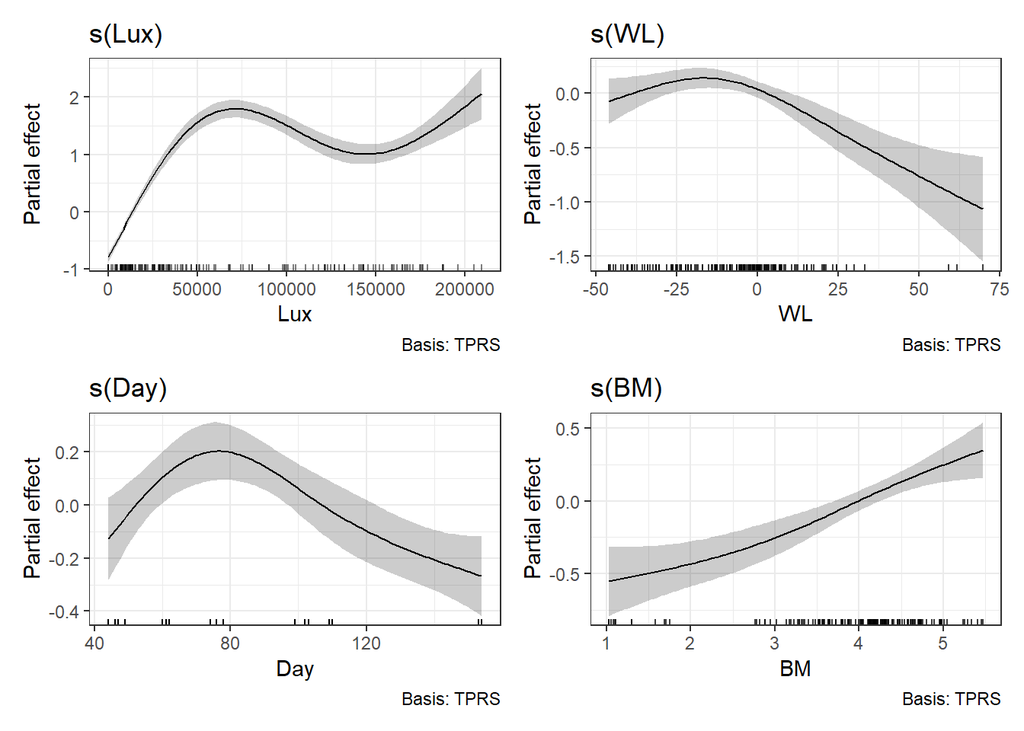

```r
draw(gam_phot3)
```

For whatever reason, this new model has a more complicated (and weird) relationship with light at high levels of intensity. Maybe that’s because a lot of our sunniest measurements came in June, when the plants hadn’t grown as much? But you’d think that would be captured in the Days Since Thaw effect.

```r
concurvity(gam_phot3)
```

```
##               para     s(Lux)     s(WL)     s(Day)     s(BM)
## worst    0.7970694 0.11688699 0.4541966 0.27951765 0.3963371
## observed 0.7970694 0.06366939 0.2319451 0.09869958 0.2434282
## estimate 0.7970694 0.08719486 0.3913066 0.23419039 0.2034637
```

There are still no concurvity issues, except maybe with Site (the parametric variable).

```r
kable(collar.cv("log.photo", c("WL", "Lux", "Day", "BM", "Site"), ld.sub, k = 4, is.log = TRUE, raw.name = "neg.photo", offset = 1), digits = 2)
```

| Size | Variables | R2 | MAE | RMS | R2.raw | MAE.raw | RMS.raw |
| --- | --- | --- | --- | --- | --- | --- | --- |
| 5 | Site BM Day Lux WL | 0.77 | 0.41 | 0.55 | 0.63 | 2.01 | 3.51 |

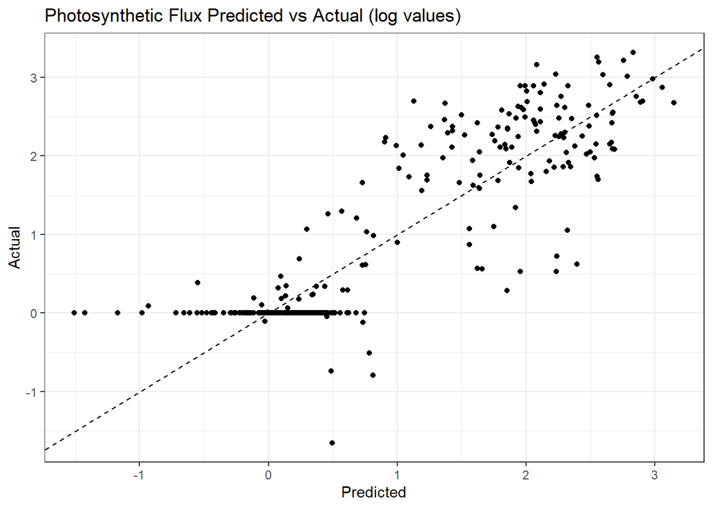

```r
photo.cv3 = collar.cv.full("log.photo", c("WL", "Lux", "Day", "BM", "Site"), ld.sub, raw.name = "neg.photo", offset = 1)

ggplot(photo.cv3, aes(x = Predicted, y = Actual)) +
  geom_point() +
  geom_abline(slope = 1, intercept = 0, lty = "dashed") +
  labs(title = "Photosynthetic Flux Predicted vs Actual (log values)")
```

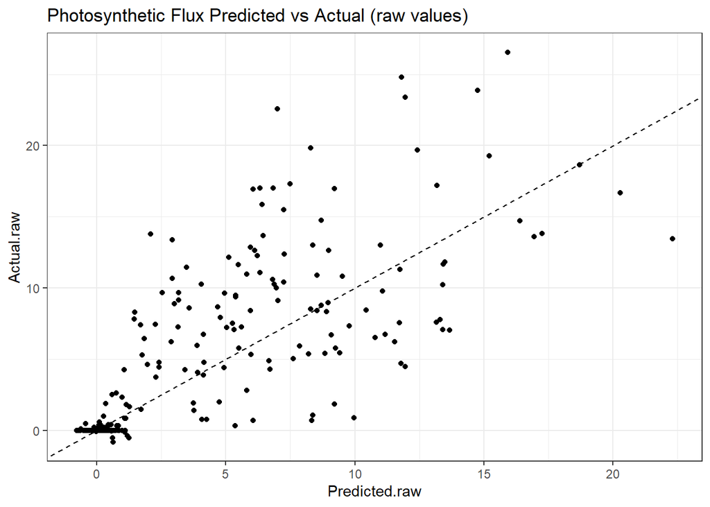

```r
ggplot(photo.cv3, aes(x = Predicted.raw, y = Actual.raw)) +
  geom_point() +
  geom_abline(slope = 1, intercept = 0, lty = "dashed") +
  labs(title = "Photosynthetic Flux Predicted vs Actual (raw values)")
```

The diagnostics for this model are a little better than those for the model without dark measurements, which makes sense I suppose - there’s a lot more clustered data. The predicted versus actual plots look decent - but it’s interesting that the GAM is predicting a range of flux values around 0 for the dark measurements. This looks much better on the raw data plot, but it’s still a little concerning. I also tried running a model with a random slope for CollarID versus Lux; the diagnostics were similar to this model - a little better for the log values, a little worse for the raw values.

## Respiration

The following section shows models for respiration - that is, flux from just dark measurements. These models exclude light intensity for obvious reasons.

### Without Collar ID

My candidate variables for respiration models without Collar ID are water level, time of year (days since thaw), log biomass, site, air temperature (corrected), soil temperature, hour of the day, and percent bare ground.

```r
# Create pared down table, shorten variable names
resp.sub = dark %>% select(CollarID, log.resp, CO2_flux_umol_m.2_sec.1, Water_Level_cm, Days_Since_Thaw, log.Biomass, Site, Mean_Temp_C_true_estimate, Soil_Temp_C, dec.hrs, bare) %>%
  rename(CO2_flux = CO2_flux_umol_m.2_sec.1,
         WL = Water_Level_cm,
         Day = Days_Since_Thaw,
         BM = log.Biomass,
         AirTemp = Mean_Temp_C_true_estimate,
         SoilTemp = Soil_Temp_C,
         Hr.of.Day = dec.hrs,
         Bare = bare)

# Run model selection (set min R2 = 0.8)
resp.select = best.sub("log.resp", c("WL", "Day", "BM", "Site", "AirTemp", "SoilTemp", "Hr.of.Day", "Bare"), max.var = 6, resp.sub, is.log = TRUE, raw.name = "CO2_flux", offset = 0, rsq.min = 0.825)  # takes a long time to run - maybe 8 variables is too many; bumped rsq.min from 0.75 to 0.8, set max.var to 6 (previous iterations found that the best model has 4 variables, so testing 7 or 8 is unnecessary)

kable(resp.select, digits = 2)
```

| Size | Variables | R2 | MAE | RMS | R2.raw | MAE.raw | RMS.raw |
| --- | --- | --- | --- | --- | --- | --- | --- |
| 6 | SoilTemp AirTemp Site BM Day WL | 0.75 | 0.33 | 0.47 | 0.74 | 1.05 | 1.54 |
| 5 | SoilTemp AirTemp BM Day WL | 0.77 | 0.33 | 0.45 | 0.74 | 1.06 | 1.55 |
| 6 | Hr.of.Day SoilTemp AirTemp BM Day WL | 0.76 | 0.33 | 0.46 | 0.74 | 1.08 | 1.55 |
| 5 | SoilTemp AirTemp Site BM WL | 0.75 | 0.34 | 0.48 | 0.74 | 1.06 | 1.54 |
| 4 | SoilTemp AirTemp BM WL | 0.76 | 0.34 | 0.46 | 0.74 | 1.07 | 1.55 |
| 6 | Hr.of.Day SoilTemp AirTemp Site BM WL | 0.74 | 0.34 | 0.48 | 0.73 | 1.09 | 1.55 |
| 4 | AirTemp BM Day WL | 0.75 | 0.34 | 0.46 | 0.72 | 1.09 | 1.59 |
| 5 | Hr.of.Day SoilTemp AirTemp BM WL | 0.75 | 0.34 | 0.47 | 0.73 | 1.10 | 1.56 |
| 5 | Hr.of.Day AirTemp BM Day WL | 0.76 | 0.34 | 0.46 | 0.73 | 1.10 | 1.55 |
| 6 | Bare Hr.of.Day AirTemp BM Day WL | 0.75 | 0.35 | 0.46 | 0.71 | 1.15 | 1.61 |
| 6 | Bare SoilTemp AirTemp BM Day WL | 0.75 | 0.35 | 0.47 | 0.70 | 1.15 | 1.64 |
| 5 | Bare AirTemp BM Day WL | 0.75 | 0.35 | 0.47 | 0.70 | 1.14 | 1.64 |
| 5 | AirTemp Site BM Day WL | 0.73 | 0.36 | 0.49 | 0.70 | 1.13 | 1.65 |
| 6 | Bare SoilTemp AirTemp Site BM WL | 0.73 | 0.36 | 0.49 | 0.71 | 1.15 | 1.63 |
| 6 | Hr.of.Day AirTemp Site BM Day WL | 0.73 | 0.36 | 0.48 | 0.71 | 1.14 | 1.61 |
| 5 | Bare SoilTemp AirTemp BM WL | 0.74 | 0.36 | 0.48 | 0.70 | 1.16 | 1.64 |
| 6 | Bare Hr.of.Day SoilTemp AirTemp BM WL | 0.74 | 0.36 | 0.48 | 0.70 | 1.18 | 1.66 |
| 6 | Bare AirTemp Site BM Day WL | 0.73 | 0.36 | 0.49 | 0.69 | 1.16 | 1.67 |

One of the best models, with an $R^2$ of 0.77, uses log biomass, days since thaw, water level, air temperature, and soil temperature. However, removing days since thaw makes very little difference, and removing soil temperature also makes little difference. This makes sense: those two variables (plus air temperature) are correlated with each other. When I run the model with these 5 variables, days since thaw has a p-value of 0.03, confirming that it’s marginal; for that reason, I’m going with just **water level, log biomass, air temperature, and soil temperature** for now. Let’s see the summary and plots for this model:

```r
gam_resp = gam(log.resp ~  s(WL, k=4) + s(BM, k=4) + s(AirTemp, k=4) + s(SoilTemp), data = resp.sub, method = "REML")
summary(gam_resp)
```

```
##
## Family: gaussian
## Link function: identity
##
## Formula:
## log.resp ~ s(WL, k = 4) + s(BM, k = 4) + s(AirTemp, k = 4) +
##     s(SoilTemp)
##
## Parametric coefficients:
##             Estimate Std. Error t value Pr(>|t|)
## (Intercept)  1.07510    0.02865   37.52   <2e-16 ***
## ---
## Signif. codes:  0 '***' 0.001 '**' 0.01 '*' 0.05 '.' 0.1 ' ' 1
##
## Approximate significance of smooth terms:
##               edf Ref.df     F p-value
## s(WL)       2.938  2.997 98.57  <2e-16 ***
## s(BM)       2.380  2.723 20.58  <2e-16 ***
## s(AirTemp)  1.647  2.029 21.98  <2e-16 ***
## s(SoilTemp) 1.000  1.000 54.05  <2e-16 ***
## ---
## Signif. codes:  0 '***' 0.001 '**' 0.01 '*' 0.05 '.' 0.1 ' ' 1
##
## R-sq.(adj) =  0.838   Deviance explained = 84.6%
## -REML = 82.614  Scale est. = 0.133     n = 162
```

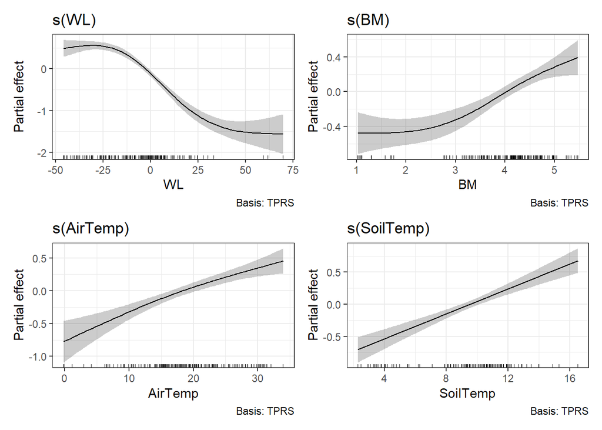

```r
draw(gam_resp)
```

The patterns here make a lot of sense. Respiration shows a sigmoidal pattern with water level, starting to decline when the water level hits ~25 cm below ground surface, then continuing to decline steeply until about 25 cm above ground surface, where it levels out at a low flux value. Respiration seems to hold relatively steady at low above-ground biomass, presumably because some respiration is always happening in the soil, then increases roughly linearly with above-ground biomass (this is still log biomass vs log respiration). The increases in respiration with air temperature and soil temperature are both roughly linear, reflecting the expected trend with temperature. Here are the concurvity values for these variables:

```r
concurvity(gam_resp)
```

```
##                  para     s(WL)     s(BM) s(AirTemp) s(SoilTemp)
## worst    6.328645e-26 0.2527992 0.2102118  0.7181419   0.7146371
## observed 6.328645e-26 0.2490117 0.1433781  0.5786251   0.5353023
## estimate 6.328645e-26 0.2389462 0.1401252  0.5607732   0.5034363
```

As expected, concurvity is high for air temperature and soil temperature, but still under 0.8 on all estimates for both.

Here are predicted versus actual values:

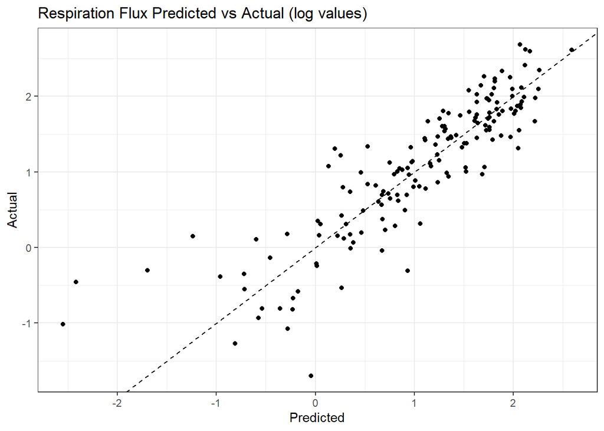

```r
resp.cv = collar.cv.full("log.resp", c("WL", "BM", "AirTemp", "SoilTemp"), resp.sub, raw.name = "CO2_flux", offset = 0)

ggplot(resp.cv, aes(x = Predicted, y = Actual)) +
  geom_point() +
  geom_abline(slope = 1, intercept = 0, lty = "dashed") +
  labs(title = "Respiration Flux Predicted vs Actual (log values)")
```

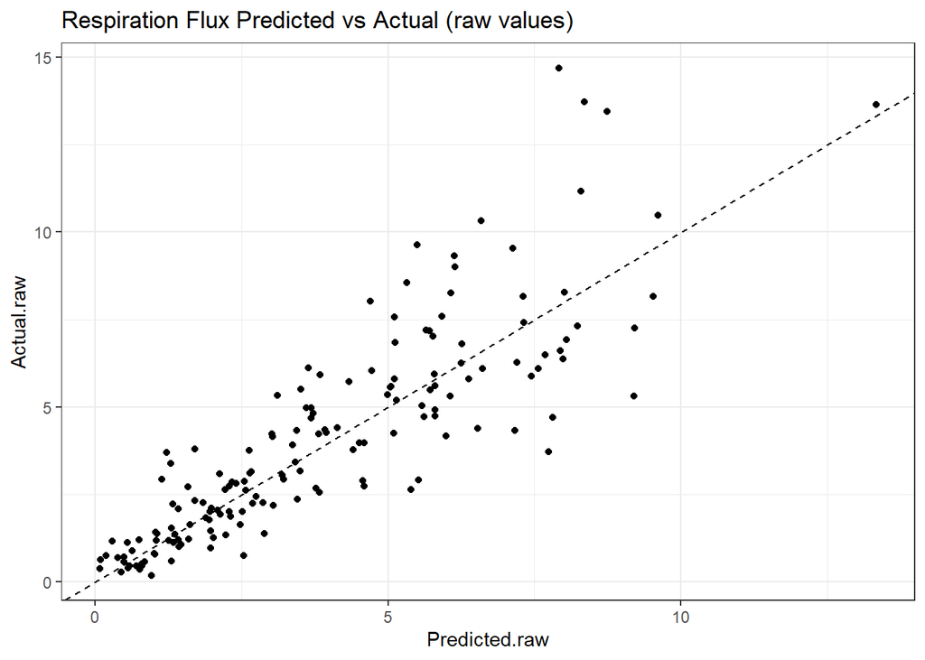

```r
ggplot(resp.cv, aes(x = Predicted.raw, y = Actual.raw)) +
  geom_point() +
  geom_abline(slope = 1, intercept = 0, lty = "dashed") +
  labs(title = "Respiration Flux Predicted vs Actual (raw values)")
```

These plots look great: points are relatively evenly divided above and below the 1:1 line across the range of respiration fluxes, both for log values and raw values. The outlier log values on the low end don’t really matter, since those fluxes are negligible anyway.

### With Collar ID as Random Effect

Next, I added Collar ID as an option and removed site and vegetation variables, like I did with photosynthesis. Here are the results:

```r
resp.select2 = best.sub("log.resp", c("WL", "Day", "AirTemp", "SoilTemp", "Hr.of.Day", "CollarID"), resp.sub, is.log = TRUE, raw.name = "CO2_flux", offset = 0, rsq.min = 0.85)
kable(resp.select2, digits = 2)
```

| Size | Variables | R2 | MAE | RMS | R2.raw | MAE.raw | RMS.raw |
| --- | --- | --- | --- | --- | --- | --- | --- |
| 4 | CollarID AirTemp Day WL | 0.82 | 0.28 | 0.38 | 0.72 | 1.01 | 1.59 |
| 4 | CollarID SoilTemp AirTemp WL | 0.82 | 0.28 | 0.38 | 0.70 | 1.04 | 1.64 |
| 5 | CollarID Hr.of.Day AirTemp Day WL | 0.82 | 0.28 | 0.38 | 0.70 | 1.06 | 1.64 |
| 5 | CollarID SoilTemp AirTemp Day WL | 0.82 | 0.29 | 0.39 | 0.69 | 1.07 | 1.67 |
| 5 | CollarID Hr.of.Day SoilTemp AirTemp WL | 0.82 | 0.29 | 0.38 | 0.70 | 1.07 | 1.64 |
| 6 | CollarID Hr.of.Day SoilTemp AirTemp Day WL | 0.82 | 0.29 | 0.38 | 0.70 | 1.08 | 1.66 |

Let’s look at the model summary and smooths:

```r
gam_resp2 = gam(log.resp ~ s(WL, k=4) + s(AirTemp, k=4) + s(SoilTemp, k=4) + s(CollarID, bs = "re"), data = resp.sub, method = "REML")
summary(gam_resp2)
```

```
##
## Family: gaussian
## Link function: identity
##
## Formula:
## log.resp ~ s(WL, k = 4) + s(AirTemp, k = 4) + s(SoilTemp, k = 4) +
##     s(CollarID, bs = "re")
##
## Parametric coefficients:
##             Estimate Std. Error t value Pr(>|t|)
## (Intercept)  1.07510    0.05734   18.75   <2e-16 ***
## ---
## Signif. codes:  0 '***' 0.001 '**' 0.01 '*' 0.05 '.' 0.1 ' ' 1
##
## Approximate significance of smooth terms:
##                edf Ref.df      F p-value
## s(WL)        2.918  2.983 77.034  <2e-16 ***
## s(AirTemp)   1.714  2.095 22.001  <2e-16 ***
## s(SoilTemp)  1.000  1.000 48.882  <2e-16 ***
## s(CollarID) 19.902 26.000  3.461  <2e-16 ***
## ---
## Signif. codes:  0 '***' 0.001 '**' 0.01 '*' 0.05 '.' 0.1 ' ' 1
##
## R-sq.(adj) =  0.861   Deviance explained = 88.3%
## -REML = 86.562  Scale est. = 0.11444   n = 162
```

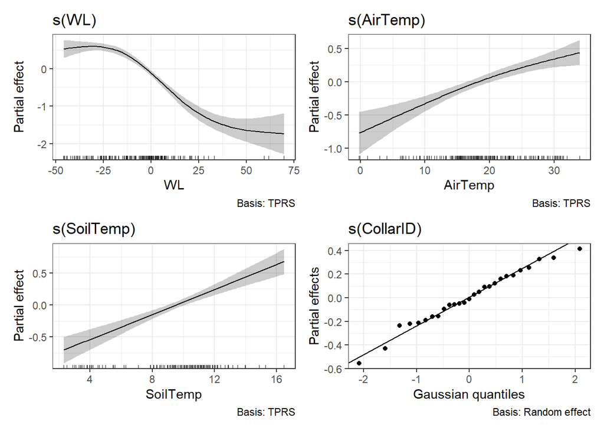

```r
draw(gam_resp2)
```

The collar partial effects follow the Gaussian quantiles quite closely. Let’s look at concurvity again:

```r
concurvity(gam_resp2)
```

```
##          para     s(WL) s(AirTemp) s(SoilTemp) s(CollarID)
## worst       1 0.6376628  0.7840149   0.7135716  1.00000000
## observed    1 0.6305188  0.7298123   0.6817456  0.04334871
## estimate    1 0.6232945  0.7072854   0.6767814  0.12914276
```

Concurvity is fairly high for all of the variables, but none of the continuous variables are above 0.8.

Here are predicted versus actual values:

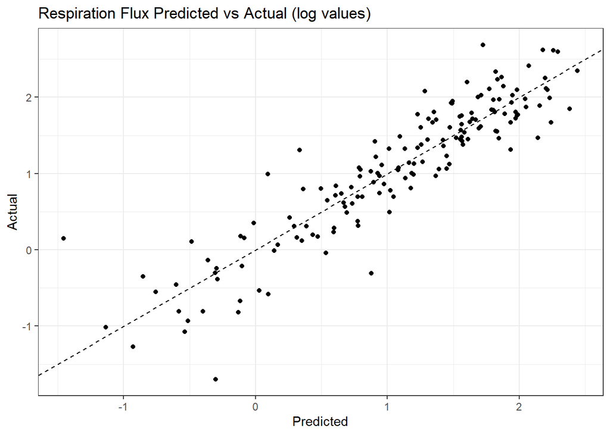

```r
resp.cv2 = collar.cv.full("log.resp", c("WL", "AirTemp", "SoilTemp", "CollarID"), resp.sub, raw.name = "CO2_flux", offset = 0)

ggplot(resp.cv2, aes(x = Predicted, y = Actual)) +
  geom_point() +
  geom_abline(slope = 1, intercept = 0, lty = "dashed") +
  labs(title = "Respiration Flux Predicted vs Actual (log values)")
```

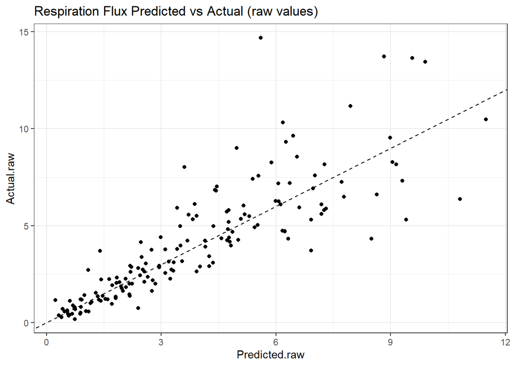

```r
ggplot(resp.cv2, aes(x = Predicted.raw, y = Actual.raw)) +
  geom_point() +
  geom_abline(slope = 1, intercept = 0, lty = "dashed") +
  labs(title = "Respiration Flux Predicted vs Actual (raw values)")
```

These plots look pretty similar to those for the previous model. Maybe a little better predictions for the low respiration measurements.

## Methane

Methane flux is harder to model than CO2 flux: the range of values between low and high methane collars is very high, making it hard to avoid large residuals. Collar seems to have a larger effect on methane flux than it does on the CO2 fluxes, as we’ll see below.

### Without Collar ID

My candidate variables for methane models without Collar ID are water level, log biomass, site, air temperature (corrected), soil temperature, hour of the day, percent bare ground, and percent high CH4 plants.

```r
# Run model selection
ch4.select = best.sub("log.CH4", c("WL","Site","BM","AirTemp", "SoilTemp", "Hr.of.Day", "Bare", "high_CH4"), dataset = ch4.sub, is.log = TRUE, raw.name = "raw.CH4", offset = 0.01, rsq.min = 0.5, max.var = 4)  # set max number of variables to 4 - having more than that doesn't help
kable(ch4.select, digits = 3)
```

| Size | Variables | R2 | MAE | RMS | R2.raw | MAE.raw | RMS.raw |
| --- | --- | --- | --- | --- | --- | --- | --- |
| 4 | high_CH4 Bare Site WL | 0.474 | 0.639 | 0.857 | 0.043 | 0.050 | 0.150 |
| 4 | Bare Hr.of.Day Site WL | 0.406 | 0.648 | 0.909 | 0.030 | 0.048 | 0.151 |
| 4 | Bare AirTemp Site WL | 0.390 | 0.673 | 0.922 | 0.027 | 0.049 | 0.151 |
| 3 | Bare Site WL | 0.390 | 0.676 | 0.922 | 0.026 | 0.049 | 0.151 |
| 3 | high_CH4 Bare WL | 0.407 | 0.681 | 0.911 | 0.056 | 0.051 | 0.148 |
| 4 | high_CH4 Bare Hr.of.Day Site | 0.384 | 0.682 | 0.931 | 0.033 | 0.051 | 0.151 |
| 2 | high_CH4 WL | 0.417 | 0.684 | 0.898 | 0.075 | 0.052 | 0.147 |
| 4 | Bare SoilTemp Site WL | 0.381 | 0.685 | 0.930 | 0.026 | 0.049 | 0.151 |
| 4 | high_CH4 Bare Hr.of.Day WL | 0.399 | 0.687 | 0.918 | 0.055 | 0.052 | 0.148 |
| 4 | high_CH4 Bare AirTemp WL | 0.402 | 0.687 | 0.915 | 0.059 | 0.051 | 0.148 |
| 3 | high_CH4 AirTemp WL | 0.415 | 0.688 | 0.900 | 0.078 | 0.052 | 0.147 |
| 3 | high_CH4 Hr.of.Day WL | 0.409 | 0.689 | 0.905 | 0.074 | 0.052 | 0.147 |
| 4 | high_CH4 AirTemp Site WL | 0.406 | 0.690 | 0.913 | 0.054 | 0.052 | 0.148 |
| 4 | high_CH4 Hr.of.Day Site WL | 0.401 | 0.690 | 0.918 | 0.047 | 0.052 | 0.149 |
| 3 | high_CH4 Site WL | 0.403 | 0.690 | 0.915 | 0.049 | 0.052 | 0.149 |
| 4 | Bare BM Site WL | 0.388 | 0.691 | 0.924 | 0.024 | 0.051 | 0.151 |
| 4 | high_CH4 Hr.of.Day AirTemp WL | 0.409 | 0.693 | 0.905 | 0.077 | 0.052 | 0.147 |
| 4 | high_CH4 Bare SoilTemp WL | 0.410 | 0.694 | 0.910 | 0.055 | 0.053 | 0.148 |
| 3 | high_CH4 Bare Site | 0.384 | 0.695 | 0.930 | 0.032 | 0.052 | 0.151 |
| 4 | high_CH4 Bare AirTemp Site | 0.381 | 0.698 | 0.933 | 0.034 | 0.052 | 0.151 |
| 4 | high_CH4 SoilTemp Site WL | 0.404 | 0.698 | 0.917 | 0.045 | 0.053 | 0.149 |
| 3 | high_CH4 SoilTemp WL | 0.418 | 0.699 | 0.899 | 0.069 | 0.053 | 0.147 |
| 4 | high_CH4 Hr.of.Day SoilTemp WL | 0.411 | 0.703 | 0.905 | 0.067 | 0.054 | 0.147 |
| 4 | high_CH4 Bare SoilTemp Site | 0.376 | 0.705 | 0.939 | 0.033 | 0.052 | 0.151 |
| 4 | high_CH4 SoilTemp AirTemp WL | 0.410 | 0.706 | 0.906 | 0.066 | 0.054 | 0.147 |
| 3 | high_CH4 BM WL | 0.315 | 0.743 | 0.997 | 0.028 | 0.055 | 0.151 |
| 4 | high_CH4 Bare BM Site | 0.340 | 0.745 | 0.970 | 0.025 | 0.055 | 0.153 |
| 4 | high_CH4 AirTemp BM WL | 0.313 | 0.746 | 0.999 | 0.030 | 0.055 | 0.151 |
| 4 | high_CH4 Hr.of.Day BM WL | 0.307 | 0.749 | 1.004 | 0.027 | 0.055 | 0.151 |
| 4 | high_CH4 Bare BM WL | 0.328 | 0.751 | 0.991 | 0.027 | 0.056 | 0.152 |
| 4 | high_CH4 BM Site WL | 0.311 | 0.754 | 1.003 | 0.025 | 0.054 | 0.151 |
| 4 | high_CH4 SoilTemp BM WL | 0.321 | 0.758 | 0.998 | 0.023 | 0.056 | 0.152 |
| 4 | high_CH4 Bare SoilTemp BM | 0.211 | 0.833 | 1.093 | 0.009 | 0.060 | 0.157 |

```r
### MAE for null model with raw data ###
# mean(abs(ch4.sub$raw.CH4 - mean(ch4.sub$raw.CH4)))
```

There are a lot of similarly predictive models here, none of them great. All of them have really low $R^2$ values for the raw data - a product of the extreme outliers - so mean average error (MAE) is probably a more useful metric for at least the raw data. For reference, the MAE for the null model (i.e., predicting every methane flux as the global average) is 0.0728. Most of the best models include %Bare ground; let’s take a look at smooths for the top model, which includes water level, %High CH4 plants, %Bare, and Site:

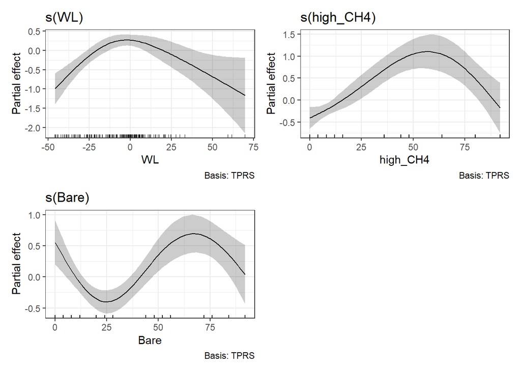

```r
gam_ch4.bare = gam(log.CH4 ~ s(WL, k = 4) + s(high_CH4, k = 4) + s(Bare, k = 4) + Site, data = ch4.sub, method = "REML")
draw(gam_ch4.bare)
```

This relationship with %Bare seems implausible to me. I guess it comes out well in the cross validation, but even still, I don’t know what physical processes would cause methane flux to go down, then up, then down as percent bare ground increases; it seems like an artifact of our specific collars. Other models that include %Bare produce roughly the same effect. The best model without %Bare includes just 2 variables, **%High CH4 plants and water level**:

```r
gam_ch4 = gam(log.CH4 ~ s(WL, k = 4) + s(high_CH4, k = 4), data = ch4.sub, method = "REML")
summary(gam_ch4)
```

```
##
## Family: gaussian
## Link function: identity
##
## Formula:
## log.CH4 ~ s(WL, k = 4) + s(high_CH4, k = 4)
##
## Parametric coefficients:
##             Estimate Std. Error t value Pr(>|t|)
## (Intercept) -3.59587    0.06448  -55.77   <2e-16 ***
## ---
## Signif. codes:  0 '***' 0.001 '**' 0.01 '*' 0.05 '.' 0.1 ' ' 1
##
## Approximate significance of smooth terms:
##               edf Ref.df     F p-value
## s(WL)       2.754  2.954 17.70  <2e-16 ***
## s(high_CH4) 2.660  2.908 33.24  <2e-16 ***
## ---
## Signif. codes:  0 '***' 0.001 '**' 0.01 '*' 0.05 '.' 0.1 ' ' 1
##
## R-sq.(adj) =  0.512   Deviance explained = 52.8%
## -REML = 206.42  Scale est. = 0.67347   n = 162
```

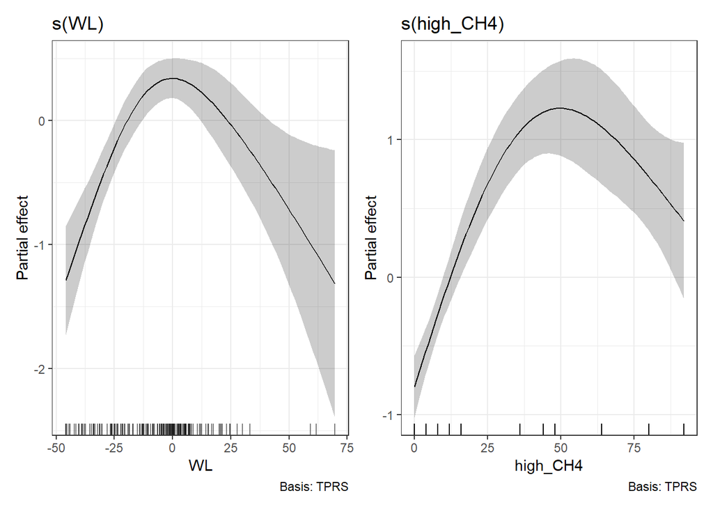

```r
draw(gam_ch4)
```

This model looks better. Methane flux increases with water level up to about the ground surface, then decreases with increased standing water. Scott Bridgham said that he’s seen this same effect in tidal collars: the hydrostatic pressure created by deeper water inhibits gas effusion. The effect of high CH4 plants is a little more puzzling: we see an increase in methane flux up to about 50% cover, but then flux decreases after that. Maybe this has to do with which plants are included in the “high methane” category; ordinating the vegetation communities could offer improvements. It’s interesting to me that soil temperature doesn’t come out as important here. I suspect if we are able to add a set of measurements with truly frozen ground, that will change.

Let’s check concurvity with these two variables:

```r
concurvity(gam_ch4)
```

```
##                 para      s(WL) s(high_CH4)
## worst    1.82641e-23 0.18670699  0.18670699
## observed 1.82641e-23 0.05356429  0.12114310
## estimate 1.82641e-23 0.17237911  0.09929348
```

I thought that water level and %High CH4 plants might be more highly correlated, but it turns out they’re pretty separate from each other. Here are the predicted vs actual graphs for raw and log values:

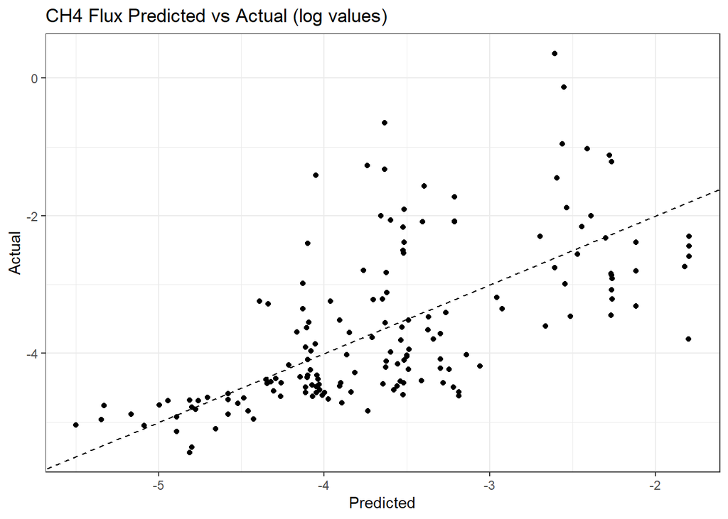

```r
ch4.cv = collar.cv.full("log.CH4", c("WL", "high_CH4"), ch4.sub, raw.name = "raw.CH4", offset = 0.01)

ggplot(ch4.cv, aes(x = Predicted, y = Actual)) +
  geom_point() +
  geom_abline(slope = 1, intercept = 0, lty = "dashed") +
  labs(title = "CH4 Flux Predicted vs Actual (log values)")
```

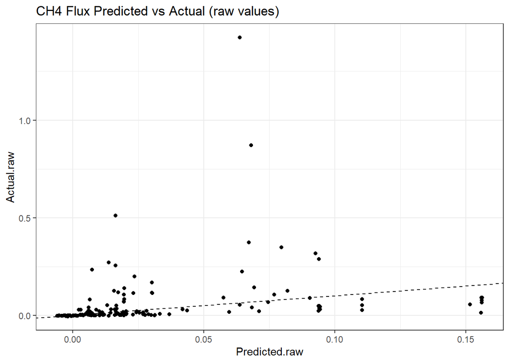

```r
ggplot(ch4.cv, aes(x = Predicted.raw, y = Actual.raw)) +
  geom_point() +
  geom_abline(slope = 1, intercept = 0, lty = "dashed") +
  labs(title = "CH4 Flux Predicted vs Actual (raw values)")
```

The plot with the log values doesn’t look too bad, though the positive residuals are larger than the negative ones.

### With Collar ID

Next, I tried to find the best model for methane flux with Collar ID included:

```r
# Run model selection with CollarID
ch4.select = best.sub("log.CH4", c("WL","AirTemp", "SoilTemp","Hr.of.Day","CollarID"), dataset = ch4.sub, is.log = TRUE, raw.name = "raw.CH4", offset = 0.01, rsq.min = 0.7)
kable(ch4.select, digits = 3)
```

| Size | Variables | R2 | MAE | RMS | R2.raw | MAE.raw | RMS.raw |
| --- | --- | --- | --- | --- | --- | --- | --- |
| 3 | CollarID SoilTemp WL | 0.735 | 0.421 | 0.603 | 0.253 | 0.039 | 0.132 |
| 4 | CollarID Hr.of.Day SoilTemp WL | 0.724 | 0.428 | 0.615 | 0.230 | 0.040 | 0.134 |
| 5 | CollarID Hr.of.Day SoilTemp AirTemp WL | 0.725 | 0.429 | 0.614 | 0.208 | 0.040 | 0.135 |
| 4 | CollarID SoilTemp AirTemp WL | 0.719 | 0.436 | 0.621 | 0.209 | 0.040 | 0.135 |
| 2 | CollarID WL | 0.700 | 0.451 | 0.641 | 0.251 | 0.040 | 0.133 |
| 3 | CollarID AirTemp WL | 0.704 | 0.452 | 0.638 | 0.287 | 0.040 | 0.131 |
| 3 | CollarID Hr.of.Day WL | 0.699 | 0.457 | 0.643 | 0.234 | 0.041 | 0.134 |
| 4 | CollarID Hr.of.Day AirTemp WL | 0.678 | 0.459 | 0.665 | 0.165 | 0.041 | 0.139 |
| 2 | CollarID SoilTemp | 0.642 | 0.495 | 0.701 | 0.241 | 0.043 | 0.134 |
| 4 | CollarID Hr.of.Day SoilTemp AirTemp | 0.629 | 0.500 | 0.714 | 0.156 | 0.044 | 0.140 |
| 3 | CollarID Hr.of.Day SoilTemp | 0.622 | 0.502 | 0.721 | 0.166 | 0.045 | 0.139 |
| 3 | CollarID SoilTemp AirTemp | 0.625 | 0.503 | 0.718 | 0.168 | 0.044 | 0.139 |

```r
gam_ch4.2 = gam(log.CH4 ~ s(WL, k = 4) + s(SoilTemp, k = 4) + s(CollarID, bs = "re"), data = ch4.sub, method = "REML")
summary(gam_ch4.2)
```

```
##
## Family: gaussian
## Link function: identity
##
## Formula:
## log.CH4 ~ s(WL, k = 4) + s(SoilTemp, k = 4) + s(CollarID, bs = "re")
##
## Parametric coefficients:
##             Estimate Std. Error t value Pr(>|t|)
## (Intercept)  -3.5959     0.1883   -19.1   <2e-16 ***
## ---
## Signif. codes:  0 '***' 0.001 '**' 0.01 '*' 0.05 '.' 0.1 ' ' 1
##
## Approximate significance of smooth terms:
##                edf Ref.df      F p-value
## s(WL)        2.768  2.949 14.927 < 2e-16 ***
## s(SoilTemp)  2.798  2.966  6.508 0.00074 ***
## s(CollarID) 24.433 26.000 13.639 < 2e-16 ***
## ---
## Signif. codes:  0 '***' 0.001 '**' 0.01 '*' 0.05 '.' 0.1 ' ' 1
##
## R-sq.(adj) =  0.781   Deviance explained = 82.2%
## -REML = 181.16  Scale est. = 0.30257   n = 162
```

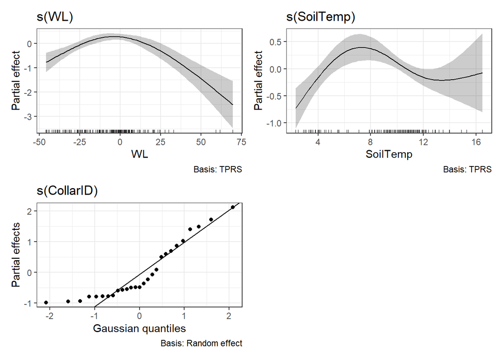

```r
draw(gam_ch4.2)
```

These results mostly make sense, though it’s unclear why methane production would decrease as soil temperature increases above ~8 degrees C. Maybe soil temp is capturing some other effect, like higher methane production associated with groundwater? The partial effects for the collars don’t really follow the Gaussian quantiles on the low end; I think the low end mostly shows the collars at West (and some at Mid) that all produce similarly low methane fluxes on a consistent basis. Let’s check concurvity:

```r
concurvity(gam_ch4.2)
```

```
##          para     s(WL) s(SoilTemp) s(CollarID)
## worst       1 0.6344371   0.4935373   1.0000000
## observed    1 0.5799865   0.3104009   0.2522007
## estimate    1 0.6127507   0.2544207   0.1137164
```

Again, water level and Collar ID are somewhat correlated. How about predicted vs actual values?

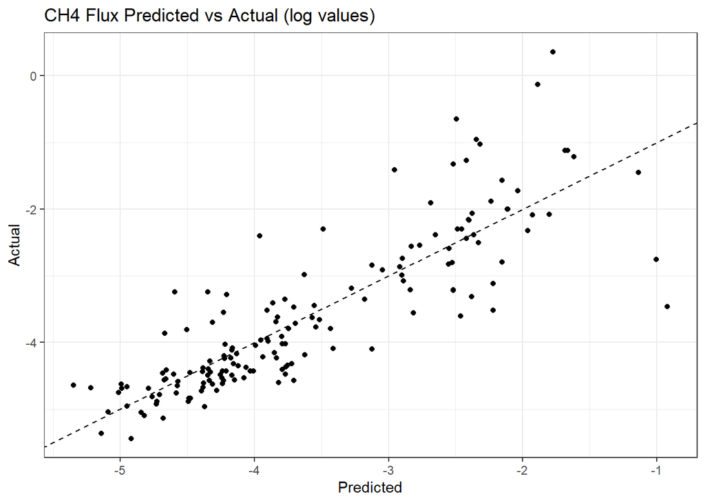

```r
ch4.cv2 = collar.cv.full("log.CH4", c("WL", "SoilTemp", "CollarID"), ch4.sub, raw.name = "raw.CH4", offset = 0.01)

ggplot(ch4.cv2, aes(x = Predicted, y = Actual)) +
  geom_point() +
  geom_abline(slope = 1, intercept = 0, lty = "dashed") +
  labs(title = "CH4 Flux Predicted vs Actual (log values)")
```

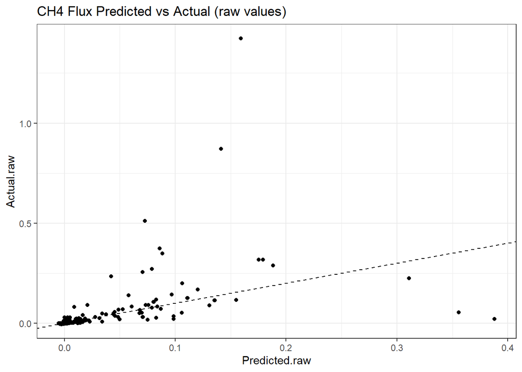

```r
ggplot(ch4.cv2, aes(x = Predicted.raw, y = Actual.raw)) +
  geom_point() +
  geom_abline(slope = 1, intercept = 0, lty = "dashed") +
  labs(title = "CH4 Flux Predicted vs Actual (raw values)")
```

Definitely an improvement on the model without Collar ID.

## Effect of Decreasing the Number of Collars

I thought it might be interesting to try cross validating the models with fewer collars in the training data set to see how sensitive they are. If predicting flux with 26 collars works a lot better than predicting with 24 collars, that would imply that adding a few more collars could provide a lot of benefit (not that we’re considering more collars with the current project). I tried this with the methane model (without Collar ID):

```r
# Try it with decreasing # of collars...
mae = list() # list to store model accuracy data
ct = 1

for (s in 1:10){  # loop through number of collars to take out of training set and put into test set
  ch4.preds.decr = list()
  count = 1

  for (i in 1:500){  # sample 1000 times for each training set size (less precision since collars will show up different numbers of times, but can't really do k-fold CV for this experiment)
    collars = sample(unique(ch4.sub$CollarID), s, replace = FALSE)
    train = ch4.sub %>% filter(!(CollarID %in% collars))
    test = ch4.sub %>% filter(CollarID %in% collars)
    mod = gam(log.CH4 ~ s(WL, k = 4) + s(high_CH4, k = 4), data = train, method = "REML")
    preds = predict.gam(mod, test)
    ch4.preds.decr[[count]] = data.frame(Predicted = preds,
                              Predicted.raw = exp(preds) - 0.01,
                              Actual = test$log.CH4,
                              Actual.raw = test$raw.CH4)
    count = count + 1
  }

  ch4.preds.decr = bind_rows(ch4.preds.decr)
  mae[[ct]] = data.frame(Collars = 27 - s,
                         R2 = cor(ch4.preds.decr$Predicted, ch4.preds.decr$Actual)^2,
                         MAE = mean(abs(ch4.preds.decr$Predicted - ch4.preds.decr$Actual)),
                         RMS = sqrt(mean((ch4.preds.decr$Predicted - ch4.preds.decr$Actual)^2)),
                         R2.raw = cor(ch4.preds.decr$Predicted.raw, ch4.preds.decr$Actual.raw)^2,   # Add raw diagnostics
                         MAE.raw = mean(abs(ch4.preds.decr$Predicted.raw - ch4.preds.decr$Actual.raw)),
                         RMS.raw = sqrt(mean((ch4.preds.decr$Predicted.raw - ch4.preds.decr$Actual.raw)^2))
  )
  ct = ct + 1
}

accuracy = bind_rows(mae)
kable(accuracy, digits = 3)
```

| Collars | R2 | MAE | RMS | R2.raw | MAE.raw | RMS.raw |
| --- | --- | --- | --- | --- | --- | --- |
| 26 | 0.411 | 0.681 | 0.892 | 0.079 | 0.051 | 0.150 |
| 25 | 0.430 | 0.670 | 0.878 | 0.077 | 0.049 | 0.141 |
| 24 | 0.408 | 0.688 | 0.909 | 0.064 | 0.054 | 0.151 |
| 23 | 0.407 | 0.690 | 0.905 | 0.066 | 0.051 | 0.143 |
| 22 | 0.393 | 0.696 | 0.923 | 0.060 | 0.054 | 0.152 |
| 21 | 0.402 | 0.699 | 0.922 | 0.064 | 0.054 | 0.150 |
| 20 | 0.348 | 0.722 | 0.971 | 0.000 | 0.074 | 0.679 |
| 19 | 0.363 | 0.715 | 0.953 | 0.001 | 0.063 | 0.389 |
| 18 | 0.367 | 0.714 | 0.946 | 0.015 | 0.055 | 0.167 |
| 17 | 0.274 | 0.749 | 1.074 | 0.016 | 0.059 | 0.171 |

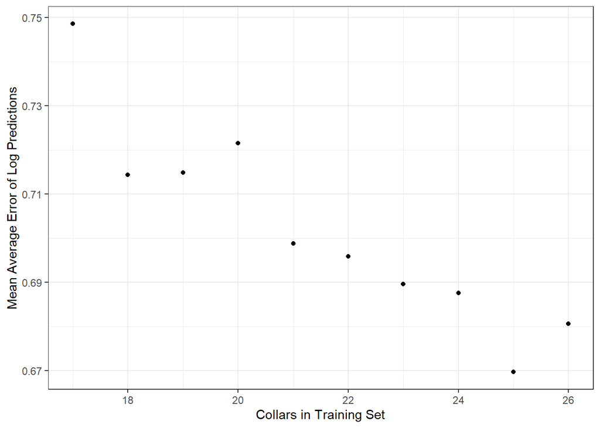

```r
ggplot(accuracy, aes(x = Collars, y = MAE)) + geom_point() + labs(x = "Collars in Training Set", y = "Mean Average Error of Log Predictions")
```

The data are somewhat noisy (which makes sense given the sampling technique), and the exact results depend on which metric you look at, but it seems like the model’s predictive accuracy drops off pretty slowly with a decreasing number of collars. This suggests we might not learn a ton from adding a few more collars.

## Effect of Transect

Finally, I wanted to check whether collar transect has a significant effect on these models. I included transect as a random variable in the model for each type of flux and cross-validated to compare to the non-transect model:

```r
photo.sub$Transect = as.factor(substr(photo.sub$CollarID,1,3))
photo.cv.t = collar.cv("log.photo", c("WL", "BM", "Lux", "Day", "Transect"), photo.sub, raw.name = "neg.photo", is.log = TRUE, k = 4, offset = 1)
photo.cv.2 = collar.cv("log.photo", c("WL", "BM", "Lux", "Day", "Site"), photo.sub, raw.name = "neg.photo", is.log = TRUE, k = 4, offset = 1)
kable(rbind(photo.cv.t, photo.cv.2), digits = 2, caption = "Photosynthetic Flux")
```

Photosynthetic Flux

| Size | Variables | R2 | MAE | RMS | R2.raw | MAE.raw | RMS.raw |
| --- | --- | --- | --- | --- | --- | --- | --- |
| 5 | Transect Day Lux BM WL | 0.72 | 0.38 | 0.53 | 0.69 | 2.57 | 3.53 |
| 5 | Site Day Lux BM WL | 0.73 | 0.36 | 0.52 | 0.73 | 2.45 | 3.34 |

```r
resp.sub$Transect = as.factor(substr(resp.sub$CollarID,1,3))
resp.cv.t = collar.cv("log.resp", c("WL", "BM", "AirTemp", "SoilTemp", "Transect"), resp.sub, raw.name = "CO2_flux", is.log = TRUE, k = 4, offset = 0)
resp.cv.2 = collar.cv("log.resp", c("WL", "BM", "AirTemp", "SoilTemp"), resp.sub, raw.name = "CO2_flux", is.log = TRUE, k = 4, offset = 0)
kable(rbind(resp.cv.t, resp.cv.2), digits = 2, caption = "Respiration Flux")
```

Respiration Flux

| Size | Variables | R2 | MAE | RMS | R2.raw | MAE.raw | RMS.raw |
| --- | --- | --- | --- | --- | --- | --- | --- |
| 5 | Transect SoilTemp AirTemp BM WL | 0.73 | 0.35 | 0.49 | 0.73 | 1.10 | 1.57 |
| 4 | SoilTemp AirTemp BM WL | 0.76 | 0.34 | 0.46 | 0.74 | 1.07 | 1.55 |

```r
ch4.sub$Transect = as.factor(substr(ch4.sub$CollarID,1,3))
ch4.cv.t = collar.cv("log.CH4", c("WL", "high_CH4", "Transect"), ch4.sub, raw.name = "raw.CH4", is.log = TRUE, k = 4, offset = 0.01)
ch4.cv.2 = collar.cv("log.CH4", c("WL", "high_CH4"), ch4.sub, raw.name = "raw.CH4", is.log = TRUE, k = 4, offset = 0.01)
kable(rbind(ch4.cv.t, ch4.cv.2), digits = 2, caption = "Methane Flux")
```

Methane Flux

| Size | Variables | R2 | MAE | RMS | R2.raw | MAE.raw | RMS.raw |
| --- | --- | --- | --- | --- | --- | --- | --- |
| 3 | Transect high_CH4 WL | 0.33 | 0.77 | 0.99 | 0.03 | 0.05 | 0.15 |
| 2 | high_CH4 WL | 0.42 | 0.68 | 0.90 | 0.08 | 0.05 | 0.15 |

All of these models get worse when you include transect. I tried adding position in the transect as well (1 = closest to stream channel, 3 = furthest away from channel), and that didn’t help either.

# Model Extrapolation: Proof of Concept with TEH3

Our ultimate goal with these data is to create models we can use to extrapolate across time and space. I decided to try out a small proof of concept by predicting gas flux for every hour at one collar - TEH3 - from June 15th (our first measurement day) to Oct 2nd (our last measurement day). This [shiny app](https://spencer-d-johnson.shinyapps.io/Test_App_TEH3/) shows the results! To be clear, this is still far from a final version of what our modelling will hopefully look like, so the actual numbers should be taken with a big grain of salt.

## Expressing Uncertainty

An important part of our site-wide modelling is going to be how certain we are in our estimates. I’ve been struggling a bit on how to conceptualize uncertainty for the gas flux data, and I’d love to get some input on this if anybody has ideas. Here are a few ideas I’ve been considering:

1. Since I’m using log-transformed data in the models, it’s going to be important to sample from the full distribution of possible model outputs to get a mean estimate of gas exchange for the site. If the log predictions have a roughly normal distribution around the mean log-transformed value, then the raw fluxes (what we actually care about) are going to have a right-skewed distribution, with a **higher** mean than the mean of our predicted values.
2. The `predict.gam` function has an option to give you the standard error of each prediction, which as far as I understand it is supposed to be the average error of a predicted value. At least, that’s what I’ve seen online, though I’m not 100% sure. For simple population statistics, standard error is the average error of the *sampling distribution* - or how far off you expect your estimate of a parameter to be from the “true parameter” - which in this case would imply that the standard error is the average deviation of the prediction from the “true value” of the model. Anyway, whatever the reason, the standard errors produced by `predict.gam` seem too small: when I create a confidence interval using the standard error and Z-values, it doesn’t come close encompassing the range of residuals I get when cross-validating the models. Part of this discrepancy probably comes from inflated prediction errors caused by our repeated measurements.

To more accurately reflect the true range of model residuals, I’ve been sampling from the actual log residuals from the cross-validated models. The downside of this approach is that doesn’t consider situations where there might be more or less uncertainty due to the source data: for example, a GAM will likely be more confident in the middle of the range of biomass values, where there’s a lot of data to build a model off of, than at the extremes where the model is only built from a few data points. I’m also wondering if higher log residuals for lower fluxes (in the case of photosynthesis and respiration) are skewing my sampling and causing me to overestimate uncertainty for the higher flux data points: some of the confidence intervals seem implausibly wide.

3. There’s also a question of precision versus accuracy (I think that applies here?), or “random error” vs “fixed error”. One way to get a total flux across time (and space) would be to just sample from the distribution of possible flux values at each point in time (and space), then add all those fluxes together (this is what I would consider accounting for “random error”). Given a sufficiently large number of points in time and/or space, this method seems like it should give you an accurate estimate of the total, but *not* an accurate estimate of uncertainty - the errors will all converge toward the same average, even if you run this sampling a bunch of times. Another strategy would be to find the upper and lower bounds of the flux confidence interval for each point in time (and space), then add all the upper bounds and lower bounds respectively to get a total confidence interval. This strategy would assume that errors are all perfectly correlated across time and space.

The reality is probably somewhere in between: there’s some “fixed,” or correlated, error, but also some random error. One way I’ve thought about implementing this is to estimate the fixed error as the percent of variation explained by collar. Collar ID, or location, is static, so if that explains most of the variation in flux, then most of the error from the model is probably going to be persistent across time, and possibly across space (I haven’t thought much about spatial autocorrelation yet). If Collar ID explains relatively little variation, then most of the error from the model is probably going to be more related to changing environmental conditions - how plants and micro-organisms respond to particular light levels, water levels, etc. The table below shows how much variation Collar ID explains in photosynthetic, respiration, and methane flux. Though I haven’t done this yet, you could use these $R^2$ values as weights in an average of the upper/lower confidence bounds and randomly sampled flux values.

```r
fixed.photo = summary(lm(log.photo ~ CollarID, data = photo.sub))$r.squared  # 0.195
fixed.resp = summary(lm(log.resp ~ CollarID, data = resp.sub))$r.squared  # 0.327
fixed.ch4 = summary(lm(log.CH4 ~ CollarID, data = ch4.sub))$r.squared  # 0.740

kable(data.frame(Photosynthesis.R2 = fixed.photo, Respiration.R2 = fixed.resp, CH4.R2 = fixed.ch4), digits = 2)
```

| Photosynthesis.R2 | Respiration.R2 | CH4.R2 |
| --- | --- | --- |
| 0.19 | 0.33 | 0.74 |

Similar to what we saw in the models above, photosynthesis seems to have little variation explained by collar (19%), while respiration has a little more (33%) and methane has much more (74%). This suggests that methane flux probably has a lot more temporal correlation than photosynthesis and respiration.

Another strategy that might work would be to build a suite of models from bootstrapped sets of collars - which could represent the fixed error - then sample randomly within those models, maybe incorporating some level of temporal or spatial autocorrelation, which would represent the random error.

## Gathering Data

I pulled together air temp, light, and soil temp data for the loggers near TEH3, then added in the other covariate data. I used `loess` smoothers (shown below) to get continuous data for water level and log biomass, neither of which changed a ton for this collar. I corrected the air temperatures using the model from earlier in this analysis. However, the temperatures still seem too extreme to be fully believable - for example, the nighttime temperature drops below freezing a few times in June. We probably need to do a wider assessment of our air temperature data; I know the beaver sites have more extreme temperatures than the coast, but they can’t be *that* much more extreme.

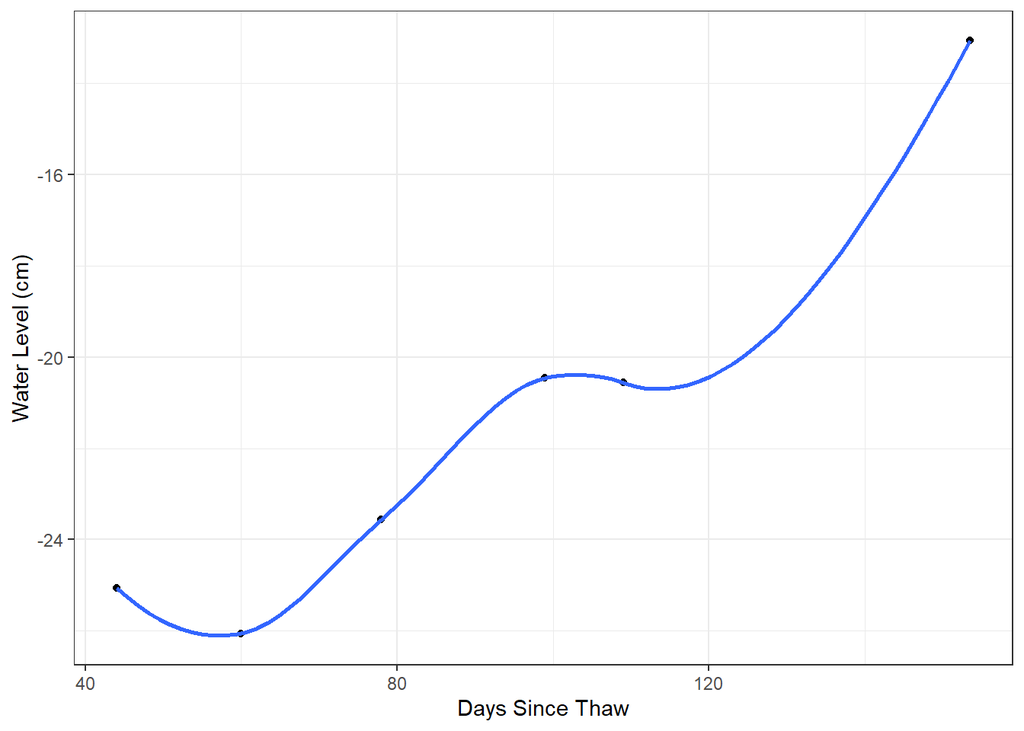

```r
# Read in logger data
teh3 = read.csv("TEH_SoilAirLight_Summer24.csv")
#glimpse(teh3)
teh3$Date = mdy(teh3$Date)
teh3$DateTime = as.POSIXct(teh3$DateTime, format = "%m/%d/%Y %H:%M", tz = "US/Aleutian")  # AKST - had to do some matching since soil temps were in AKDT; also, our new soil logger hasn't been recording on the hour (it's recording on the 49th minute), which probably doesn't matter for soil temp but it's a bit annoying
teh3$Days_Since_Thaw = (yday(teh3$DateTime) - yday(mdy("5/2/2024"))) + hour(teh3$DateTime)/24

# Convert air temps to estimate of true temp using GAM with light intensity
teh3$AirTemp_C = teh3$AirTemp_C - predict(gam_temp, newdata = data.frame(mean_lux = teh3$Intensity_LUX))

ch4.teh3 = ch4.sub %>% filter(CollarID == "TEH3")
ch4.teh3$Days_Since_Thaw[6] = 153.5  # to get to end of time period for soil temp/light/air temp

# Use loess smoothers for water level and biomass - not perfect (and barely enough data), but good enough for now
wl.mod = loess(WL ~ Days_Since_Thaw, data = ch4.teh3)
bm.mod = loess(BM ~ Days_Since_Thaw, data = ch4.teh3)

ggplot(ch4.teh3, aes(x = Days_Since_Thaw, y = WL)) +
  geom_point() +
  geom_smooth() +
  labs(x = "Days Since Thaw", y = "Water Level (cm)")
```

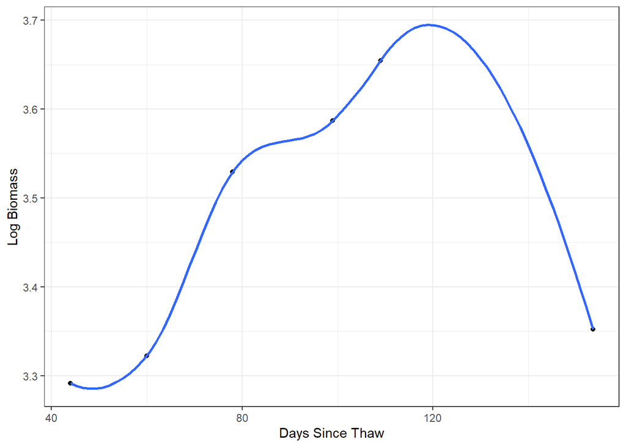

```r
ggplot(ch4.teh3, aes(x = Days_Since_Thaw, y = BM)) +
  geom_point() +
  geom_smooth() +
  labs(x = "Days Since Thaw", y = "Log Biomass")
```

```r
teh3$Water_Level_cm = predict(wl.mod, newdata = teh3$Days_Since_Thaw)
teh3$Log_Biomass = predict(bm.mod, newdata = teh3$Days_Since_Thaw)
teh3$Site = as.factor(rep("East", nrow(teh3)))
teh3$Pct_High_CH4 = rep(mean(ch4.teh3$high_CH4), nrow(teh3))
teh3$CollarID = as.factor(rep("TEH3", nrow(teh3)))

kable(head(teh3))
```

| X. | DateTime | Date | Time_GMT.09.00 | AirTemp_C | Intensity_LUX | SoilTemp_C | Days_Since_Thaw | Water_Level_cm | Log_Biomass | Site | Pct_High_CH4 | CollarID |
| --- | --- | --- | --- | --- | --- | --- | --- | --- | --- | --- | --- | --- |
| 1 | 2024-06-15 11:00:00 | 2024-06-15 | 11:00:00 | 21.74885 | 132267.5 | 10.736 | 44.45833 | -25.13084 | 3.290255 | East | 16 | TEH3 |
| 2 | 2024-06-15 12:00:00 | 2024-06-15 | 12:00:00 | 24.59485 | 41333.6 | 10.712 | 44.50000 | -25.13715 | 3.290158 | East | 16 | TEH3 |
| 3 | 2024-06-15 13:00:00 | 2024-06-15 | 13:00:00 | 23.05018 | 104711.8 | 10.712 | 44.54167 | -25.14345 | 3.290062 | East | 16 | TEH3 |
| 4 | 2024-06-15 14:00:00 | 2024-06-15 | 14:00:00 | 24.66008 | 71644.9 | 10.736 | 44.58333 | -25.14973 | 3.289967 | East | 16 | TEH3 |
| 5 | 2024-06-15 15:00:00 | 2024-06-15 | 15:00:00 | 26.35642 | 21355.7 | 10.834 | 44.62500 | -25.15598 | 3.289874 | East | 16 | TEH3 |
| 6 | 2024-06-15 16:00:00 | 2024-06-15 | 16:00:00 | 23.97019 | 20666.8 | 10.956 | 44.66667 | -25.16221 | 3.289781 | East | 16 | TEH3 |

```r
# Make new version with names matched to GAMs
t = teh3 %>% rename(Day = Days_Since_Thaw,
                    AirTemp = AirTemp_C,
                    SoilTemp = SoilTemp_C,
                    Lux = Intensity_LUX,
                    BM = Log_Biomass,
                    WL = Water_Level_cm,
                    high_CH4 = Pct_High_CH4)
```

## Methane Predictions

First, I predicted methane without Collar ID. The predictions vs measurements in the chamber are shown below. See the [shiny app](https://spencer-d-johnson.shinyapps.io/Test_App_TEH3/) for the June to October site predictions.

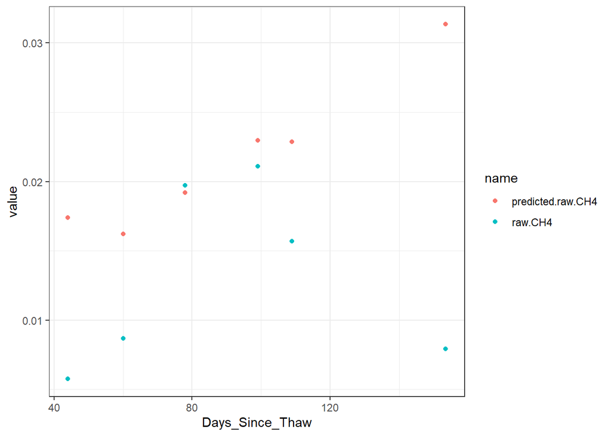

```r
# Plot predicted methane (without Collar ID) vs actual methane in the collar measurements
ch4.teh3$predicted.raw.CH4 = exp(predict(gam_ch4, ch4.teh3)) - 0.01
ggplot(ch4.teh3 %>% pivot_longer(c(raw.CH4, predicted.raw.CH4)), aes(x = Days_Since_Thaw, y = value, color = name)) +
  geom_point()
```

```r
# Generate predictions for full June-Oct data
CH4.1 = predict.gam(gam_ch4, newdata = t)
# Get model prediction residuals, find 95% CI quantiles for those residuals
resid.ch4 = ch4.cv$Actual - ch4.cv$Predicted
q = quantile(resid.ch4, probs = c(0.025, 0.975))

# Calculate true (raw) values for predicted flux, flux sampled from distribution of log model residuals, upper CI bound for flux from log model residuals, and lower CI bound for flux from log model residuals
teh3$CH4.flux = exp(CH4.1) - 0.01
teh3$CH4.flux.sampled = exp(CH4.1 + sample(resid.ch4, size = length(CH4.1), replace = TRUE)) - 0.01
teh3$CH4.flux.upper = exp(CH4.1 + q[2]) - 0.01
teh3$CH4.flux.lower = exp(CH4.1 + q[1]) - 0.01
```

Next, I did the same thing for the methane model with Collar ID:

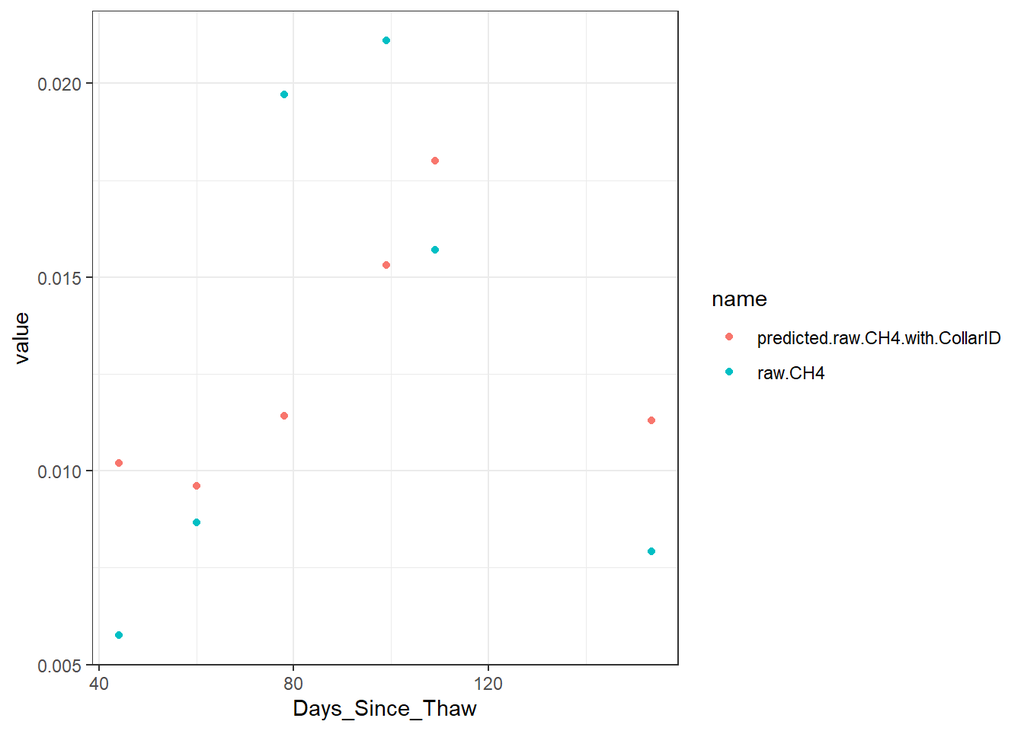

```r
ch4.teh3$predicted.raw.CH4.with.CollarID = exp(predict(gam_ch4.2, ch4.teh3)) - 0.01
ggplot(ch4.teh3 %>% pivot_longer(c(raw.CH4, predicted.raw.CH4.with.CollarID)), aes(x = Days_Since_Thaw, y = value, color = name)) +
  geom_point()
```

```r
CH4.2 = predict.gam(gam_ch4.2, newdata = t)
resid.ch4.2 = ch4.cv2$Actual - ch4.cv2$Predicted
q = quantile(resid.ch4.2, probs = c(0.025, 0.975))

teh3$CH4.flux.collar = exp(CH4.2) - 0.01
teh3$CH4.flux.collar.sampled = exp(CH4.2 + sample(resid.ch4.2, size = length(CH4.2), replace = TRUE)) - 0.01
teh3$CH4.flux.collar.upper = exp(CH4.2 + q[2]) - 0.01
teh3$CH4.flux.collar.lower = exp(CH4.2 + q[1]) - 0.01
```

For this collar, the methane predictions aren’t *too* bad, and get better in the model with Collar ID.

## Respiration Predictions

Next, I plotted predicted versus actual values for respiration within the chamber (without Collar ID).

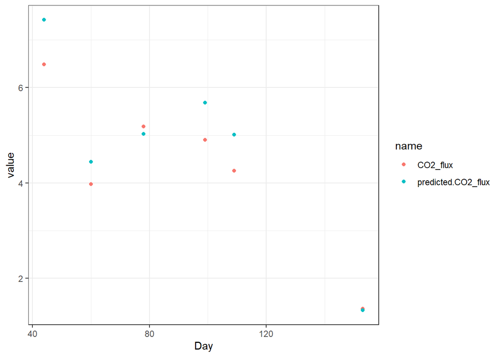

```r
resp.teh3 = resp.sub %>% filter(CollarID == "TEH3")

resp.teh3$predicted.CO2_flux = exp(predict(gam_resp, resp.teh3))
ggplot(resp.teh3 %>% pivot_longer(c(CO2_flux, predicted.CO2_flux)), aes(x = Day, y = value, color = name)) +
  geom_point()
```

```r
resp.1 = predict.gam(gam_resp, newdata = t)
resid.resp = resp.cv$Actual - resp.cv$Predicted
q = quantile(resid.resp, probs = c(0.025, 0.975))

teh3$resp.flux = exp(resp.1)
teh3$resp.flux.sampled = exp(resp.1 + sample(resid.resp, size = length(resp.1), replace = TRUE))
teh3$resp.flux.upper = exp(resp.1 + q[2])
teh3$resp.flux.lower = exp(resp.1 + q[1])
```

Here we have the same thing with the model that includes Collar ID:

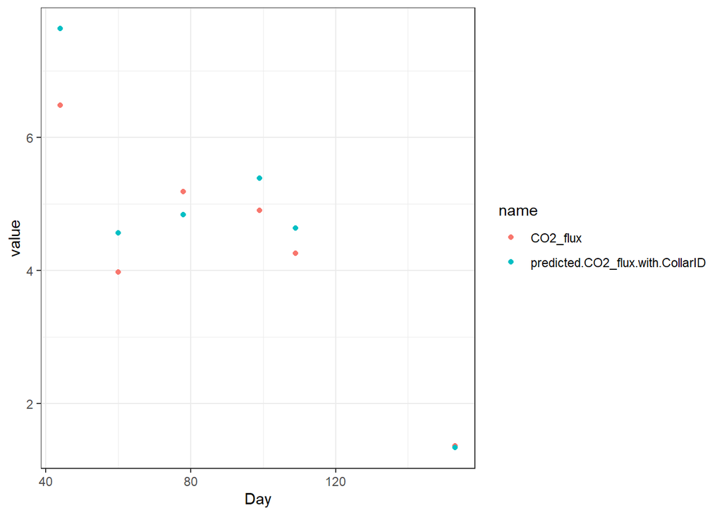

```r
resp.teh3$predicted.CO2_flux.with.CollarID = exp(predict(gam_resp2, resp.teh3))
ggplot(resp.teh3 %>% pivot_longer(c(CO2_flux, predicted.CO2_flux.with.CollarID)), aes(x = Day, y = value, color = name)) +
  geom_point()
```

```r
resp.2 = predict.gam(gam_resp2, newdata = t)
resid.resp.2 = resp.cv2$Actual - resp.cv2$Predicted
q = quantile(resid.resp.2, probs = c(0.025, 0.975))

teh3$resp.flux.collar = exp(resp.2)
teh3$resp.flux.collar.sampled = exp(resp.2 + sample(resid.resp.2, size = length(resp.2), replace = TRUE))
teh3$resp.flux.collar.upper = exp(resp.2 + q[2])
teh3$resp.flux.collar.lower = exp(resp.2 + q[1])
```

In both respiration models, the predictions are pretty spot on for TEH3.

## Photosynthesis Predictions

Same process with photosynthesis, showing predicted vs actual for the model without Collar ID that includes dark measurements. I skipped the model with Collar ID since it was a slightly worse model.

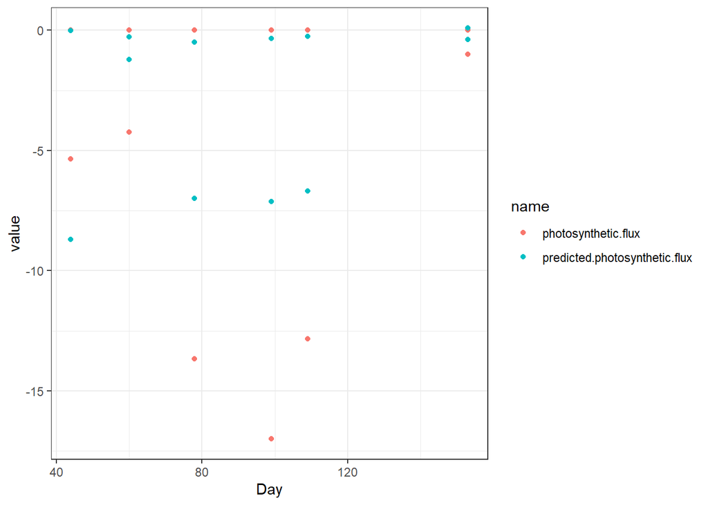

```r
photo.teh3 = ld.sub %>% filter(CollarID == "TEH3")

photo.teh3$predicted.photosynthetic.flux = -exp(predict(gam_phot3, photo.teh3)) + 1
ggplot(photo.teh3 %>% rename(photosynthetic.flux = raw.photo) %>% pivot_longer(c(photosynthetic.flux, predicted.photosynthetic.flux)),
       aes(x = Day, y = value, color = name)) +
       geom_point()
```

```r
photo.1 = predict.gam(gam_phot3, newdata = t)
resid.photo = photo.cv3$Actual - photo.cv3$Predicted
q = quantile(resid.photo, probs = c(0.025, 0.975))

teh3$photo.flux = -exp(photo.1) + 1
teh3$photo.flux.sampled = -exp(photo.1 + sample(resid.photo, size = length(photo.1), replace = TRUE)) + 1
teh3$photo.flux.lower = -exp(photo.1 + q[2]) + 1
teh3$photo.flux.upper = -exp(photo.1 + q[1]) + 1
```

The model underestimates photosynthesis quite a bit for the mid to late summer measurements at TEH3. The vegetation really grew in at TEH3 after June (see photos in the [app](https://spencer-d-johnson.shinyapps.io/Test_App_TEH3/)), so I’m guessing the model is underestimating relative biomass at the collar in July and August. There’s also significant error in the first two measurements - I’m guessing because the first measurement was really sunny, while the second was quite overcast. The deltas for those two data points weren’t as high before I added in the dark measurements. All of the dark measurement predictions are pretty close to 0, though not exactly 0.

## Net CO2 Predictions

Finally, I added photosynthesis and respiration together to get net CO2 flux predictions. Here’s a plot of predicted vs actual using the models without CollarID. I skipped the models with CollarID.

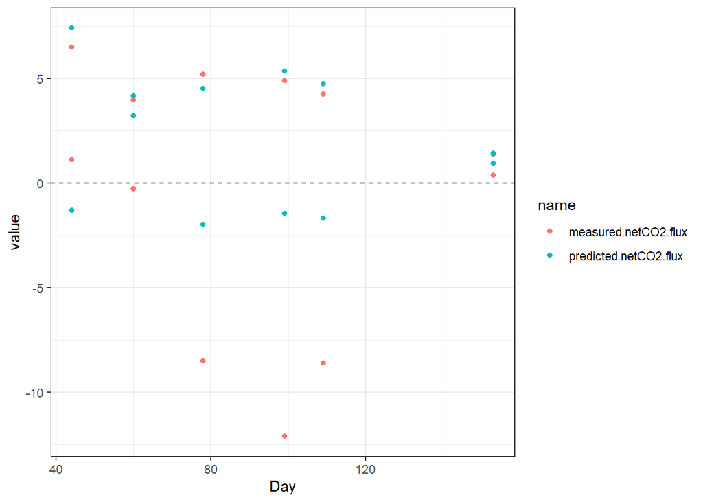

```r
# Join photosynthesis TEH3 summary table with part of respiration TEH3 summary table
co2.teh3 = photo.teh3 %>% inner_join(resp.teh3 %>% select(CO2_flux, predicted.CO2_flux, predicted.CO2_flux.with.CollarID, SoilTemp, Day), by = "Day")

# Get predicted and actual values by adding photo and resp
co2.teh3$predicted.netCO2.flux = co2.teh3$predicted.photosynthetic.flux + co2.teh3$predicted.CO2_flux
co2.teh3$measured.netCO2.flux = co2.teh3$raw.photo + co2.teh3$CO2_flux

ggplot(co2.teh3 %>% pivot_longer(c(measured.netCO2.flux, predicted.netCO2.flux)),
       aes(x = Day, y = value, color = name)) +
       geom_hline(yintercept = 0, lty = "dashed") +
       geom_point()
```

```r
teh3$CO2.flux = teh3$resp.flux + teh3$photo.flux
# Add sampled data from resp and sampled data from photo
teh3$CO2.flux.sampled = teh3$resp.flux.sampled + teh3$photo.flux.sampled
# For upper and lower confidence intervals, combine error from photo and resp by taking square root of sum of squared errors. This is a method used in propagating error through addition; it assumes that the two sources of error are independent, which may not be totally true, but it seems better than just adding the uncertainties together, which would assume they are perfectly correlated.
teh3$CO2.flux.upper = teh3$CO2.flux + sqrt((teh3$photo.flux.upper - teh3$photo.flux)^2 + (teh3$resp.flux.upper - teh3$resp.flux)^2)
teh3$CO2.flux.lower = teh3$CO2.flux - sqrt((teh3$photo.flux.lower - teh3$photo.flux)^2 + (teh3$resp.flux.lower - teh3$resp.flux)^2)

# ggplot(teh3, aes(x = CO2.flux, y = CO2.flux.sampled - CO2.flux)) + geom_point()  # see sampled error distribution by CO2 flux

# write.csv(teh3, "TEH3_FluxData.csv")
# write.csv(ch4.sub, "CH4.Modelling.Data.csv")
# save(gam_phot, file = "E:/Gas_Flux_R/Test_App_TEH3/gam_phot.rda")
```

Again, you can see the high error in the photosynthesis predictions. The dark measurement predictions just show the error in the respiration model.

# Next steps

Here are some ideas I’m considering moving forward:

1. I’d still like to try incorporating past water levels using our continuous data from the wells - particularly for methane. It seems like methane emissions depend at least somewhat on how long a site has been flooded: for example, at West, we saw basically flat methane just after flooding in July, and increasing methane in late August even as water levels went down a little bit. Methane emissions at West were still quite low compared to East, so I don’t know how big the benefit would be for modelling. We could incorporate past water levels through a moving average, or a weighted moving average (maybe exponentially weighted?), though I don’t have a clear idea on the best lag time/weighting scheme. There could also be challenges in translating the well data to individual collars: some collars are quite far from the wells in their transects. I was thinking about just running linear regressions of water levels from the collar piezometers vs the nearest well water levels, but the whether that works very well is to be determined.
2. We could try some more models beyond GAMs. I tried simple versions of regression trees (`rpart`) and a model tree (`cubist`) for methane flux with poor results - the cross-validated accuracy was worse than the null model. However, I suspect that those models could be made better through ensemble techniques (like boosting - as other researchers have done to model methane - or `randomForest()`). Other machine learning techniques might be useful to try as well.
3. As I mention above, I want to do some more work on temperature correction - running another experiment at a weather station, maybe over a wider temperature range, and deploying a shaded temperature logger at one of the sites for comparison. I also want to deploy a sensor facing direct sunlight at the sites as another comparison point.
4. It would be great to try incorporating data from vegetation ordinations (e.g., ordination-defined groupings of plant species, or axis scores).
5. I found a [site](https://ecogambler.netlify.app/blog/interpreting-gams/#step-2-simulating-from-fitted-gam-models) recently that has a lot of good information on using and interpreting GAMS, including some better ways to plot smooths (including incorporating the raw or transformed data points). Those techniques would be useful for future iterations of analysis, both for better interpretation and for formal presentation.
6. We are still hoping to get some frozen/winter data this year, which would improve the models. Getting data from earlier in the spring will also help, as will more summer data.
7. Incorporating pressure data from the barologgers into the gas flux calculations could be helpful.
8. There’s a lot we still need to figure out about site level estimation - how to generalize our various vegetation data sitewide (Lindsey and Rhiannon may have a plan for this), how to extrapolate the other environmental variables sitewide, how to represent uncertainty, how to determine where the models apply (e.g., we can’t model spruce trees from our data), etc.